# trying_glm

Milla Juntunen

2022-07-13

*** TRYING TO USE GLM FOR CURVE FITTING ***

This code tries to use the glm() to model the mortality rate after giving prehospital blood transfusions. This code is a work in process, not ready due to some problems described below.

```r
library("ggfortify")
```

```r
library("readxl")
library("ggplot2")
library("dplyr")
library("npreg")
library("ggformula")
```

Reading data from excel. Trying first with data that uses PRBCs (packed red blood cells) for prehospital transfusion. Y axis has the mortality percentage, X-axis the time in minutes.

```r
# Reading the data from excel (time in minutes AND PROBABILITIES IN DECIMAL NUMBER)
df <- read_excel("C:\\Projektit\\whole_blood_research\\excel\\Emergencyprocess_PHBT_splines.xlsx", sheet = "Sheet1")
PRBCS_data <- filter(df, products == "O-negative PRBCs" )

print(PRBCS_data)
```

```
## # A tibble: 5 × 10
##   Article       `Link to source` products  time mortality_perce… mortality n_tot
##   <chr>         <chr>            <chr>    <dbl>            <dbl>     <dbl> <dbl>
## 1 Civilian pre… https://onlinel… O-negat…  1440             16.1     0.161    56
## 2 <NA>          <NA>             O-negat… 10080             21.4     0.214    56
## 3 <NA>          <NA>             O-negat… 43200             21.4     0.214    56
## 4 Mortality of… https://www.ncb… O-negat…   360             10       0.1      92
## 5 <NA>          <NA>             O-negat… 40320             26       0.26     78
## # … with 3 more variables: n_dead <dbl>, n_survived <dbl>, ArticleAbbr <chr>
```

Testing different models to see which one is the best fit. First mortality ~ log(time), without link functions.

```r
p <- glm(mortality ~ log(time), data = PRBCS_data)
p
```

```
##
## Call:  glm(formula = mortality ~ log(time), data = PRBCS_data)
##
## Coefficients:
## (Intercept)    log(time)
##    -0.05025      0.02749
##
## Degrees of Freedom: 4 Total (i.e. Null);  3 Residual
## Null Deviance:       0.01499
## Residual Deviance: 0.001581  AIC: -20.11
```

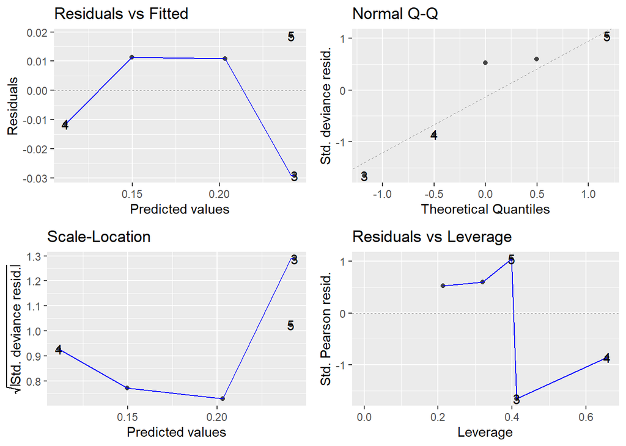

```r
autoplot(p) # for mortality ~ log(time)
```

Trying then with mortality ~ time, using gaussian and log link

```r
p <- glm(mortality ~ time, data = PRBCS_data, family = gaussian(link="log"))
p
```

```
##
## Call:  glm(formula = mortality ~ time, family = gaussian(link = "log"),
##     data = PRBCS_data)
##
## Coefficients:
## (Intercept)         time
##  -1.897e+00    1.119e-05
##
## Degrees of Freedom: 4 Total (i.e. Null);  3 Residual
## Null Deviance:       0.01499
## Residual Deviance: 0.006212  AIC: -13.26
```

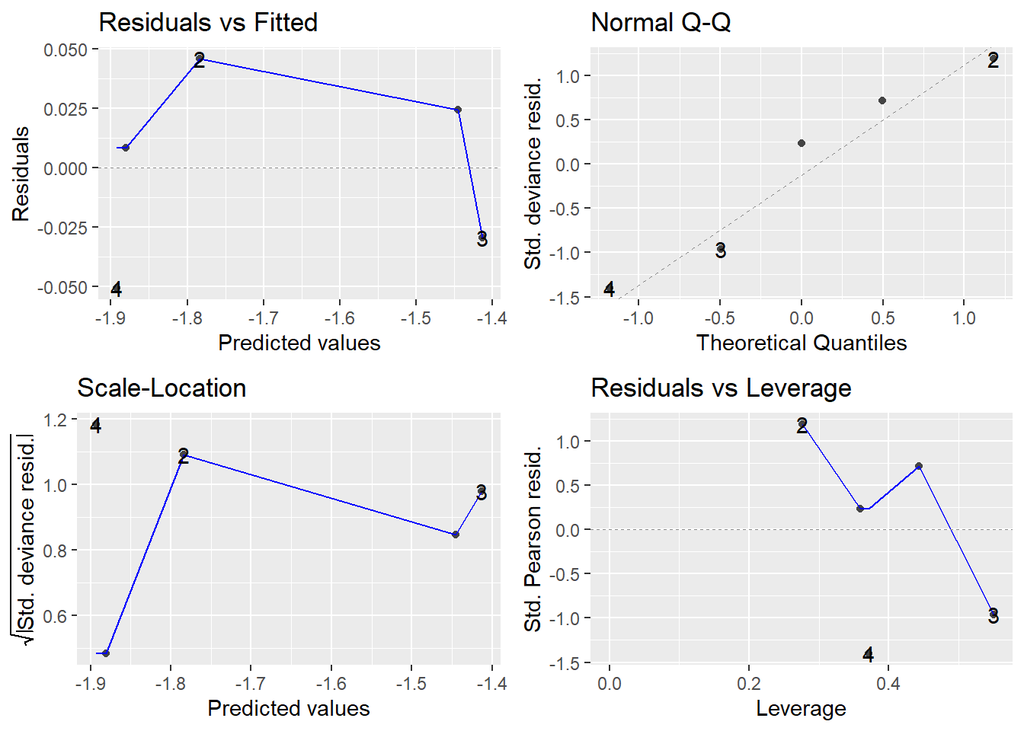

```r
autoplot(p) # for gaussian(link = "log")
```

Trying mortality ~ time, usin Gamma with log link

```r
p <- glm(mortality ~ time, data = PRBCS_data, family = Gamma(link="log"))
p
```

```
##
## Call:  glm(formula = mortality ~ time, family = Gamma(link = "log"),
##     data = PRBCS_data)
##
## Coefficients:
## (Intercept)         time
##  -1.926e+00    1.247e-05
##
## Degrees of Freedom: 4 Total (i.e. Null);  3 Residual
## Null Deviance:       0.5013
## Residual Deviance: 0.2369    AIC: -12.14
```

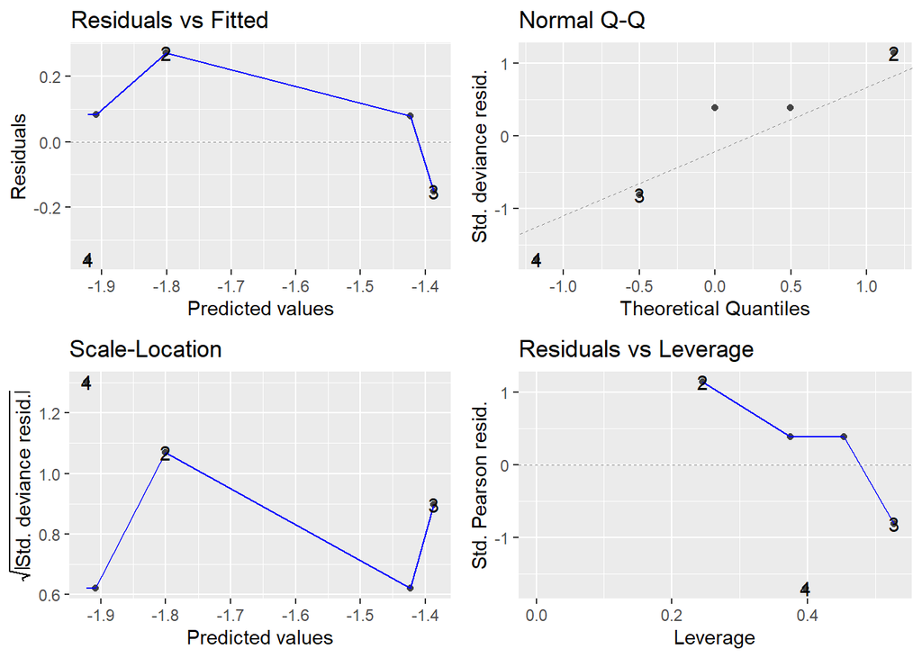

```r
autoplot(p) # for gamma(link = "log")
```